# Jonathan Nusantara (jan265)

### SVM

#### Finally, we experimented with Support Vector Machine. The SVM is a type of non-parametric classifier that maps the training set into a space and separate the different labels with a hyperplane that maximizes the distance between the two closest points. The SVM can use a kernel trick to classify a non-linearly separable data. We will be looking into the linear SVM that works only with linearly separable data and Radial Basis Functions SVM that will be able to classify non-linearly separable data. The RBF SVM have a gaussian function and has KNN-like properties. So, it is like a smoothed-version of KNN due to the gaussian function. We will compare the two SVM models' train and test time and their testing accuracy.

```python
# rescale training and testing to be less
first_index = int(60000/2)
second_index = int(60000/2+10000/2)
X_train, X_test = X[:first_index], X[first_index:second_index]
y_train, y_test = y[:first_index], y[first_index:second_index]
```

```
Training time 89.546 seconds
Test time 22.098 seconds
Test score with Linear SVM is: 0.9258
Confusion matrix, without normalization
```

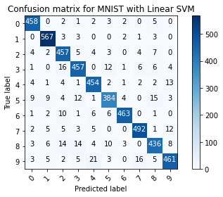

```python
## Linear Support-Vector Machine

start_time = time.time()
SVC1 = SVC(kernel = 'linear', C = 1)

#Train the classifier
SVC1.fit(X_train,y_train)
train_time_svc1 = time.time() - start_time
print("Training time %.3f seconds" % train_time_svc1)

#Evaluate the result
start_time = time.time()
score_svc1 = SVC1.score(X_test,y_test)
test_time_svc1 = time.time() - start_time
print("Test time %.3f seconds" % test_time_svc1)
print("Test score with Linear SVM is: %.4f" % score_svc1)

#Confusion Matrix
y_predict = SVC1.predict(X_test)
cfm = confusion_matrix(y_test, y_predict)
plot_confusion_matrix(cfm, classes=range(10), title='Confusion matrix for MNIST with Linear SVM')
```

```
Training time 1958.121 seconds
Test time 126.264 seconds
Test score with Radial-Basis SVM is: 0.2504
Confusion matrix, without normalization
```

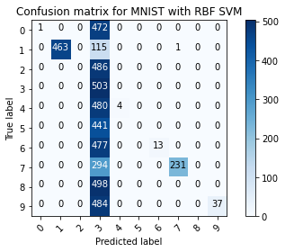

```python
## Radial Basis Functions Support-Vector Machine

start_time = time.time()
SVC2 = SVC(kernel = 'rbf', C = 1, gamma = 0.5) # initially C = 1 gamma = 0.5

#Train the classifier
SVC2.fit(X_train,y_train)
train_time_svc2 = time.time() - start_time
print("Training time %.3f seconds" % train_time_svc2)

#Evaluate the result
start_time = time.time()
score_svc2 = SVC2.score(X_test,y_test)
test_time_svc2 = time.time() - start_time
print("Test time %.3f seconds" % test_time_svc2)
print("Test score with Radial-Basis SVM is: %.4f" % score_svc2)

#Confusion Matrix
y_predict = SVC2.predict(X_test)
cfm = confusion_matrix(y_test, y_predict)
plot_confusion_matrix(cfm, classes=range(10), title='Confusion matrix for MNIST with RBF SVM')
```

```python
table = [["Linear SVM",train_time_svc1,test_time_svc1,score_svc1],["RBF SVM",train_time_svc2,test_time_svc2,score_svc2]]
print(tabulate(table, headers=["Classifier","Train time (s)", "Test time (s)", "Score"]))
```

[output not shown]

#### Due to the low test performance of the RBF SVM, I have decided to experiment with the PCA. The n input parameters that are tested are 20, 40, and 60.

```
Training time 64.096 seconds
Test time 4.039 seconds
Test score with 3NN is: 0.4422
Confusion matrix, without normalization
```

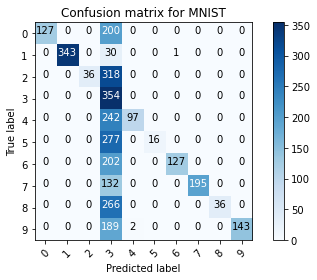

```python
first_index = int(60000/1)
second_index = int(60000/1+10000/1)

pca = PCA(n_components=40)
pca.fit(X_train, y_train)

start_time = time.time()
SVC3 = SVC(kernel = 'rbf', C = 1, gamma = 0.5) # initially C = 1 gamma = 0.5
SVC3.fit(pca.transform(X_train),y_train)
train_time_svc3 = time.time() - start_time
print("Training time %.3f seconds" % train_time_svc3)

#Evaluate the result
start_time = time.time()
score_svc3 = SVC3.score(pca.transform(X_test),y_test)
test_time_svc3 = time.time() - start_time
print("Test time %.3f seconds" % test_time_svc3)
print("Test score with 3NN is: %.4f" % score_svc3)

#Confusion Matrix
y_predict = SVC3.predict(pca.transform(X_test))
cfm = confusion_matrix(y_test, y_predict)
plot_confusion_matrix(cfm, classes=range(10), title='Confusion matrix for MNIST')
```

```
Training time 82.432 seconds
Test time 5.210 seconds
Test score with 3NN is: 0.3387
Confusion matrix, without normalization
```

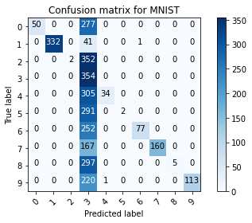

```python
first_index = int(60000/1)
second_index = int(60000/1+10000/1)

pca = PCA(n_components=60)
pca.fit(X_train, y_train)

start_time = time.time()
SVC4 = SVC(kernel = 'rbf', C = 1, gamma = 0.5) # initially C = 1 gamma = 0.5
SVC4.fit(pca.transform(X_train),y_train)
train_time_svc4 = time.time() - start_time
print("Training time %.3f seconds" % train_time_svc4)

#Evaluate the result
start_time = time.time()
score_svc4 = SVC4.score(pca.transform(X_test),y_test)
test_time_svc4 = time.time() - start_time
print("Test time %.3f seconds" % test_time_svc4)
print("Test score with 3NN is: %.4f" % score_svc4)

#Confusion Matrix
y_predict = SVC4.predict(pca.transform(X_test))
cfm = confusion_matrix(y_test, y_predict)
plot_confusion_matrix(cfm, classes=range(10), title='Confusion matrix for MNIST')
```

```
Training time 40.839 seconds
Test time 2.453 seconds
Test score with 3NN is: 0.7864
Confusion matrix, without normalization
```

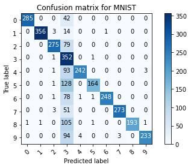

```python
pca = PCA(n_components=20)
pca.fit(X_train, y_train)

start_time = time.time()
SVC5 = SVC(kernel = 'rbf', C = 1, gamma = 0.5) # initially C = 1 gamma = 0.5
SVC5.fit(pca.transform(X_train),y_train)
train_time_svc5 = time.time() - start_time
print("Training time %.3f seconds" % train_time_svc5)

#Evaluate the result
start_time = time.time()
score_svc5 = SVC5.score(pca.transform(X_test),y_test)
test_time_svc5 = time.time() - start_time
print("Test time %.3f seconds" % test_time_svc5)
print("Test score with 3NN is: %.4f" % score_svc5)

#Confusion Matrix
y_predict = SVC5.predict(pca.transform(X_test))
cfm = confusion_matrix(y_test, y_predict)
plot_confusion_matrix(cfm, classes=range(10), title='Confusion matrix for MNIST')
```

```python
table = [["Linear SVM",train_time_svc1,test_time_svc1,score_svc1],["RBF SVM",train_time_svc2,test_time_svc2,score_svc2],["RBF SVM with PCA n=20",train_time_svc5,test_time_svc5,score_svc5],["RBF SVM with PCA n=40",train_time_svc3,test_time_svc3,score_svc3],["RBF SVM with PCA n=60",train_time_svc4,test_time_svc4,score_svc4]]
print(tabulate(table, headers=["Classifier","Train time (s)", "Test time (s)", "Score"]))
```

[output not shown]

#### After performing PCA, we can see improvements in the testing accuracy, along with much lower train and test times. The best testing accuracy is when n is the smallest at n=20. When n is smaller, it also has less train and test times. The improvement in test accuracy may be because of less overfitting after performing PCA, which will reduce the dimension of the dataset. From the above experiment, we have learned that PCA helps to an extent in improving the test accuracy of RBF SVM, although the accuracy is still rather low compared to a linear SVM (0.78 vs 0.93).

```python
table = [["KNN 1 neighbor",train_time_knn1,test_time_knn1,score_knn1],["KNN 3 neighbors",train_time_knn3,test_time_knn3,score_knn3],["KNN 5 neighbors",train_time_knn5,test_time_knn5,score_knn5]]
print(tabulate(table, headers=["Classifier","Train time (s)", "Test time (s)", "Score"]))
print()
table = [["1 hidden-layer MLP",train_time_mlp1,test_time_mlp1,score_mlp1],["2 hidden-layer MLP",train_time_mlp2,test_time_mlp2,score_mlp2]]
print(tabulate(table, headers=["Classifier","Train time (s)", "Test time (s)", "Score"]))
print()
table = [["Linear SVM",train_time_svc1,test_time_svc1,score_svc1],["RBF SVM",train_time_svc2,test_time_svc2,score_svc2],["RBF SVM with PCA n=20",train_time_svc5,test_time_svc5,score_svc5],["RBF SVM with PCA n=40",train_time_svc3,test_time_svc3,score_svc3],["RBF SVM with PCA n=60",train_time_svc4,test_time_svc4,score_svc4]]
print(tabulate(table, headers=["Classifier","Train time (s)", "Test time (s)", "Score"]))
```

[output not shown]